# presentation slides

## Boston municipal authorities 🚔⭐️🚔

### Advisory mission investigating 🔦:

**- Nature of crimes that take place in Boston**

**- Potential time trends identification**

**- Heterogeneity of the impact of criminality on the different police districts**

[figure not shown]

## Nature of crimes 🧐

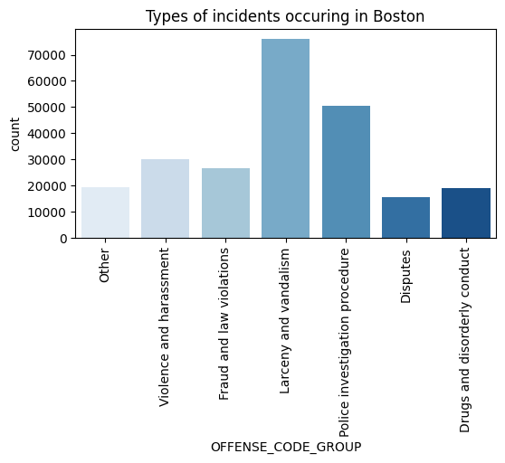

## Time trends identification ⏰

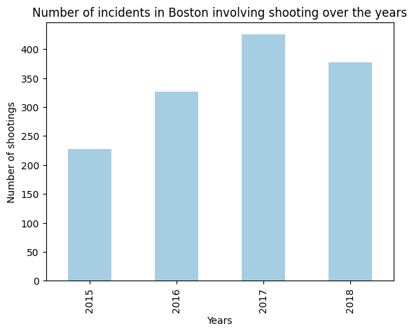

## Heterogeneity of the impact of criminality on the different police districts 🕵️‍♂️

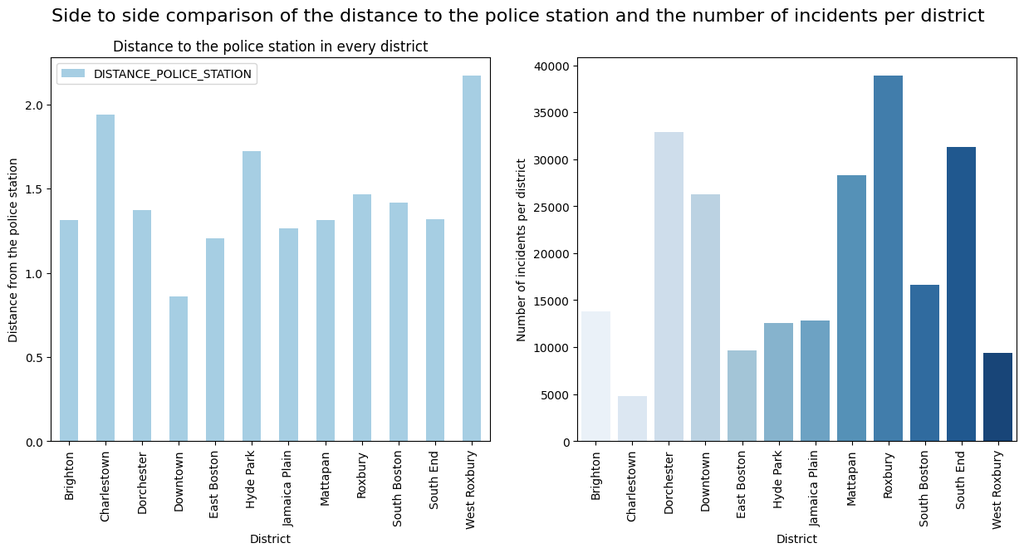

## Conclusion and projections moving forward

**Our exploration showed that :**

**- The most common categories of incidents are, in almost every district, the following :**

1 : Larceny and vandalism

2 : Police investigation procedure

**- Gun violence continually grew until 2017 but is starting to decrease since 2018, which is a good** **sign**

**- A bigger distance from a district to the police station doesn't seem to be particularly impactful on the number of incidents**

Our advice to the head of the Police Department of Boston would be to focus on mobile patrols that could potentially lower the high larceny in particular neighborhoods. We would recommend as well to focus the efforts on neighborhoods like Dorchester, Downtown, Mattapan, Roxbury, and South End.

Moving forward, we would like to explore the time of the day those incidents happen, to see if there is a difference during daytime and nightime, and see if we can do something about it. We would also look into the social economic background of the districts experiencing most troubles, to see if allocating more budget to public education, for exemple, could help us solving these issues mid-term.